# HealthInsuranceCrossSellPrediction

### Context

#### Our client is an Insurance company, wants to increase its insurance sales by providing health insurance to the current auto insurance holder. They have some past data about demographics (gender, age, region code), Vehicles (Vehicle Age, Damage), Policty (Premium, sourcing channel), and their response to hold auto insurance. Based, on this data we need to create a model, that will predict customers will be willing to participate in purchasing health insurance in future. This project will visualize the provided data, create an algorithm that best represnt the data, and test the model in the test data.

#### This project includes two parts: 1) Exploratory data analysis through visualization & 2) model building: data will be cleaned and prepared for modelling based on the visualizations.

```python
# Import all necessary models

import numpy as np
import pandas as pd
import matplotlib.pyplot as plt
import seaborn as sns

from sklearn.model_selection import train_test_split

from sklearn.neighbors import KNeighborsClassifier
from sklearn.linear_model import LogisticRegression
from sklearn.svm import SVC
from sklearn.tree import DecisionTreeClassifier
from sklearn.ensemble import RandomForestClassifier
from sklearn.ensemble import GradientBoostingClassifier

from sklearn.model_selection import cross_val_score
from sklearn.metrics import confusion_matrix
from sklearn.metrics import accuracy_score
from sklearn.metrics import precision_score
from sklearn.metrics import recall_score
from sklearn.metrics import f1_score
```

```python
# import datafile

df = pd.read_csv('train.csv')
```

```python
df.head()
```

|  | id | Gender | Age | Driving_License | Region_Code | Previously_Insured | Vehicle_Age | Vehicle_Damage | Annual_Premium | Policy_Sales_Channel | Vintage | Response |
| --- | --- | --- | --- | --- | --- | --- | --- | --- | --- | --- | --- | --- |
| 0 | 1 | Male | 44 | 1 | 28.0 | 0 | > 2 Years | Yes | 40454.0 | 26.0 | 217 | 1 |
| 1 | 2 | Male | 76 | 1 | 3.0 | 0 | 1-2 Year | No | 33536.0 | 26.0 | 183 | 0 |
| 2 | 3 | Male | 47 | 1 | 28.0 | 0 | > 2 Years | Yes | 38294.0 | 26.0 | 27 | 1 |
| 3 | 4 | Male | 21 | 1 | 11.0 | 1 | < 1 Year | No | 28619.0 | 152.0 | 203 | 0 |
| 4 | 5 | Female | 29 | 1 | 41.0 | 1 | < 1 Year | No | 27496.0 | 152.0 | 39 | 0 |

### 1. Exploratory Data Analysis

```python
# get a summary of the dataset

df.info()
```

```
<class 'pandas.core.frame.DataFrame'>
RangeIndex: 381109 entries, 0 to 381108
Data columns (total 12 columns):
 #   Column                Non-Null Count   Dtype
---  ------                --------------   -----
 0   id                    381109 non-null  int64
 1   Gender                381109 non-null  object
 2   Age                   381109 non-null  int64
 3   Driving_License       381109 non-null  int64
 4   Region_Code           381109 non-null  float64
 5   Previously_Insured    381109 non-null  int64
 6   Vehicle_Age           381109 non-null  object
 7   Vehicle_Damage        381109 non-null  object
 8   Annual_Premium        381109 non-null  float64
 9   Policy_Sales_Channel  381109 non-null  float64
 10  Vintage               381109 non-null  int64
 11  Response              381109 non-null  int64
dtypes: float64(3), int64(6), object(3)
memory usage: 34.9+ MB
```

```python
# Display summary statistics in a table

df.describe()
```

|  | id | Age | Driving_License | Region_Code | Previously_Insured | Annual_Premium | Policy_Sales_Channel | Vintage | Response |
| --- | --- | --- | --- | --- | --- | --- | --- | --- | --- |
| count | 381109.000000 | 381109.000000 | 381109.000000 | 381109.000000 | 381109.000000 | 381109.000000 | 381109.000000 | 381109.000000 | 381109.000000 |
| mean | 190555.000000 | 38.822584 | 0.997869 | 26.388807 | 0.458210 | 30564.389581 | 112.034295 | 154.347397 | 0.122563 |
| std | 110016.836208 | 15.511611 | 0.046110 | 13.229888 | 0.498251 | 17213.155057 | 54.203995 | 83.671304 | 0.327936 |
| min | 1.000000 | 20.000000 | 0.000000 | 0.000000 | 0.000000 | 2630.000000 | 1.000000 | 10.000000 | 0.000000 |
| 25% | 95278.000000 | 25.000000 | 1.000000 | 15.000000 | 0.000000 | 24405.000000 | 29.000000 | 82.000000 | 0.000000 |
| 50% | 190555.000000 | 36.000000 | 1.000000 | 28.000000 | 0.000000 | 31669.000000 | 133.000000 | 154.000000 | 0.000000 |
| 75% | 285832.000000 | 49.000000 | 1.000000 | 35.000000 | 1.000000 | 39400.000000 | 152.000000 | 227.000000 | 0.000000 |
| max | 381109.000000 | 85.000000 | 1.000000 | 52.000000 | 1.000000 | 540165.000000 | 163.000000 | 299.000000 | 1.000000 |

```python
# Group numeric and categoric variables into separate tables

df_cat = df[['Gender','Driving_License','Previously_Insured','Vehicle_Age','Vehicle_Damage']]
df_num = df[['Response','Age','Region_Code','Annual_Premium','Vintage','Policy_Sales_Channel']]
```

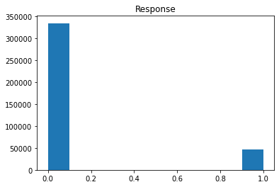

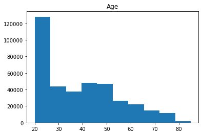

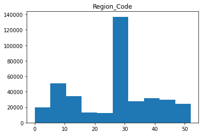

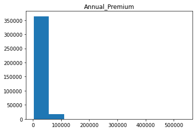

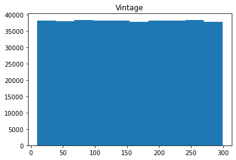

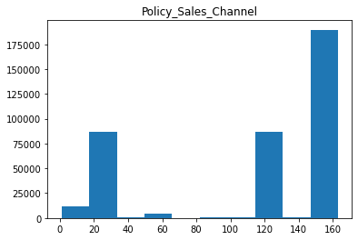

```python
for i in df_num.columns:
    plt.hist(df_num[i])
    plt.title(i)
    plt.show()
```

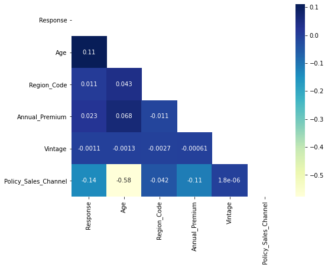

```python
# lets plot the correlation map
plt.figure(figsize = (8, 6))
# creating mask
mask = np.triu(np.ones_like(df_num.corr()))

# plotting a triangle correlation heatmap
dataplot = sns.heatmap(df_num.corr(), cmap="YlGnBu", annot=True, mask=mask)

# displaying heatmap
plt.show()
```

```python
# Find average values of variables based on response through pivot table

pd.pivot_table(df, index='Response', values=['Age','Region_Code','Annual_Premium','Vintage','Policy_Sales_Channel'])
```

| Response | Age | Annual_Premium | Policy_Sales_Channel | Region_Code | Vintage |
| --- | --- | --- | --- | --- | --- |
| 0 | 38.178227 | 30419.160276 | 114.851040 | 26.336544 | 154.380243 |
| 1 | 43.435560 | 31604.092742 | 91.869086 | 26.762963 | 154.112246 |

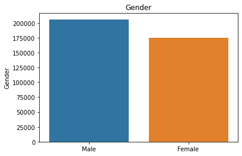

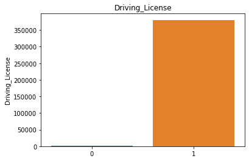

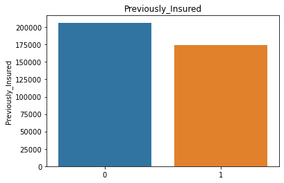

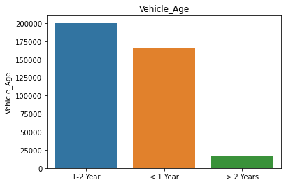

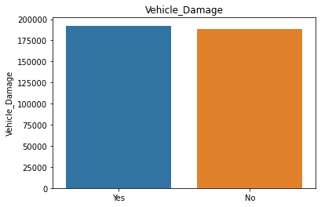

```python
for i in df_cat.columns:
    sns.barplot(df_cat[i].value_counts().index,df_cat[i].value_counts()).set_title(i)
    plt.show()
```

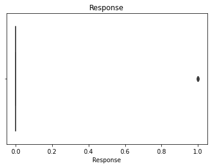

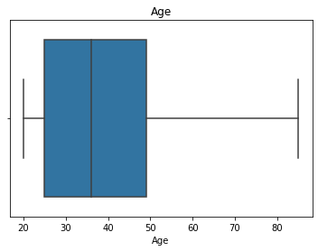

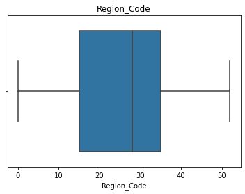

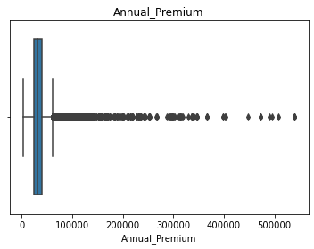

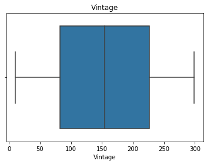

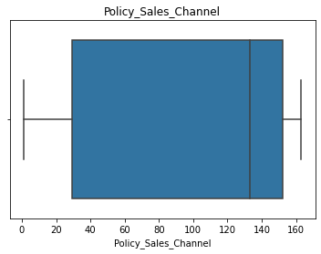

```python
# Lets see if outliers is a problem in our data

for i in df_num.columns:
    sns.boxplot(df_num[i])
    plt.title(i)
    plt.show()
```

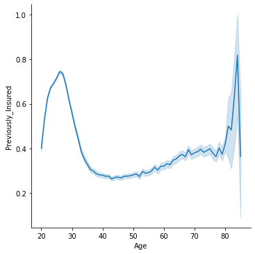

```python
# Age vs Previously Insured

sns.relplot(data=df,x='Age',y='Previously_Insured',kind='line')
```